# Sampling and Uncertainty

Can We Trust Our Estimates?

Carolina Torreblanca

University of Pennsylvania

**Global Development**: Intermediate Topics in Politics, Policy, and Data

PSCI 3200 - Spring 2026

## Agenda

1. Where does data come from? (Sampling)
2. What makes a sample trustworthy? (Representativeness)
3. How much should we trust any one estimate? (Uncertainty)
4. Reading regression output with confidence

# Where Does Data Come From?

## Population vs. Sample

**Population:** every unit we care about

- All countries, all voters, all households in a district

**Sample:** the subset we actually observe

- 80 countries with available data, 1,200 survey respondents

The goal of statistics: learn about the **population** from the **sample**.

## Sampling Methods

- **Random sample:** every unit has a known probability of being selected
- **Stratified sample:** divide population into groups, sample from each
- **Convenience sample:** whoever is easiest to reach
- **Census:** observe the entire population (rare and expensive)

## How Sampling Goes Wrong

**Examples from development research:**

- Survey only urban areas → miss rural poverty
- Phone surveys → miss people without phones
- Only villages near roads → miss remote populations
- Household surveys → miss homeless, displaced, migrant populations
- Voluntary response → people with strong opinions over-represented

# Representativeness

## What Makes a Sample Representative?

A sample is representative when its characteristics **match** the population’s characteristics.

- If 60% of the population is rural, ~60% of the sample should be rural
- If the average income is $2,000, the sample average should be close to $2,000
- This happens naturally with **random sampling** — but not with convenience samples

## Simulation: Representative vs. Biased Samples

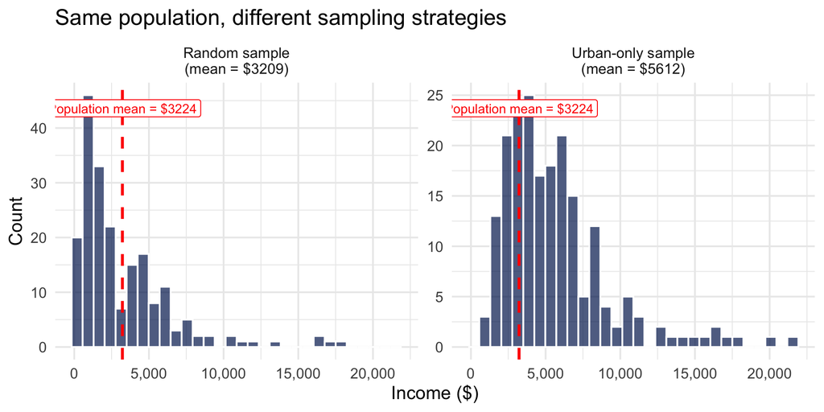

```r
library(ggplot2)

set.seed(42)

# Create a "population" of 10,000 people
population <- data.frame(
  income = c(rlnorm(7000, log(1500), 0.8),  # rural: lower income
             rlnorm(3000, log(5000), 0.6)),  # urban: higher income
  type = c(rep("Rural", 7000), rep("Urban", 3000))
)

# Random sample (representative)
random_sample <- population[sample(1:10000, 200), ]

# Biased sample (only urban)
urban_only <- population[population$type == "Urban", ]
biased_sample <- urban_only[sample(1:nrow(urban_only), 200), ]

pop_mean <- mean(population$income)
random_mean <- mean(random_sample$income)
biased_mean <- mean(biased_sample$income)

samples <- rbind(
  data.frame(income = random_sample$income, sample = paste0("Random sample\n(mean = $", round(random_mean), ")")),
  data.frame(income = biased_sample$income, sample = paste0("Urban-only sample\n(mean = $", round(biased_mean), ")"))
)

ggplot(samples, aes(x = income)) +
  geom_histogram(fill = "#011F5B", alpha = 0.7, bins = 30, color = "white") +
  geom_vline(xintercept = pop_mean, color = "red", linewidth = 1.2, linetype = "dashed") +
  facet_wrap(~sample, scales = "free_y") +
  annotate("label", x = pop_mean, y = Inf, vjust = 2,
           label = paste0("Population mean = $", round(pop_mean)),
           color = "red", size = 4) +
  labs(x = "Income ($)", y = "Count",
       title = "Same population, different sampling strategies") +
  theme_minimal(base_size = 16) +
  scale_x_continuous(labels = scales::comma)
```

## The Problem with Biased Samples

- The urban-only sample **overestimates** the population average
- Any conclusions we draw from this sample will be **misleading**
- This is **selection bias** — the sample isn’t representative
- No amount of fancy statistics can fix a bad sample

**Lesson:** before trusting any result, ask: “Where did this data come from?”

# The Sampling Distribution

## A Thought Experiment

Imagine you could sample 200 countries, compute the average life expectancy, then…

- Throw out the sample
- Draw a new sample of 200 countries
- Compute the average again
- Repeat this 1,000 times

What would the **distribution of those averages** look like?

## Let’s Find Out: 1 Sample

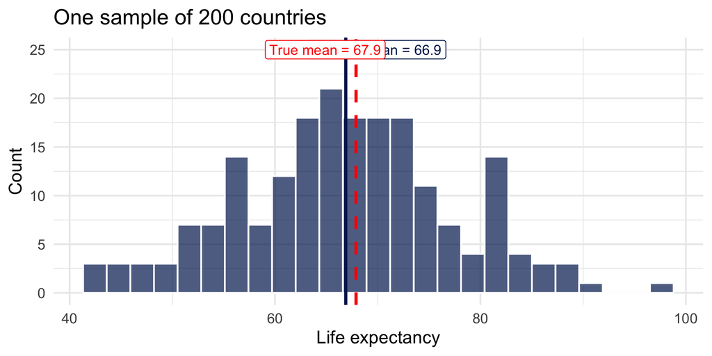

```r
set.seed(42)

# True population
pop_size <- 10000
pop_life <- rnorm(pop_size, mean = 68, sd = 10)
true_mean <- mean(pop_life)

# Draw ONE sample
one_sample <- sample(pop_life, 200)

ggplot(data.frame(x = one_sample), aes(x = x)) +
  geom_histogram(fill = "#011F5B", alpha = 0.7, bins = 25, color = "white") +
  geom_vline(xintercept = mean(one_sample), color = "#011F5B", linewidth = 1.5) +
  geom_vline(xintercept = true_mean, color = "red", linewidth = 1.5, linetype = "dashed") +
  annotate("label", x = mean(one_sample) + 3, y = 25,
           label = paste0("Sample mean = ", round(mean(one_sample), 1)),
           color = "#011F5B", size = 5) +
  annotate("label", x = true_mean - 3, y = 25,
           label = paste0("True mean = ", round(true_mean, 1)),
           color = "red", size = 5) +
  labs(x = "Life expectancy", y = "Count",
       title = "One sample of 200 countries") +
  theme_minimal(base_size = 18)
```

## Now 1,000 Samples

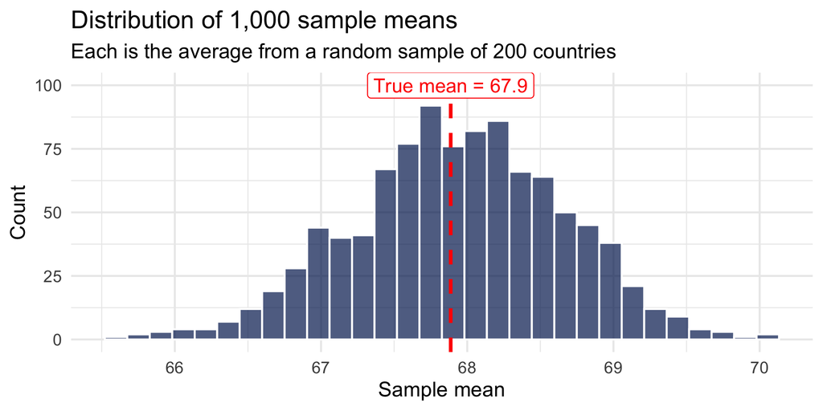

```r
set.seed(42)
n_sims <- 1000
sample_means <- numeric(n_sims)

for (i in 1:n_sims) {
  sample_means[i] <- mean(sample(pop_life, 200))
}

ggplot(data.frame(means = sample_means), aes(x = means)) +
  geom_histogram(fill = "#011F5B", alpha = 0.7, bins = 30, color = "white") +
  geom_vline(xintercept = true_mean, color = "red", linewidth = 1.5, linetype = "dashed") +
  annotate("label", x = true_mean, y = 100,
           label = paste0("True mean = ", round(true_mean, 1)),
           color = "red", size = 6) +
  labs(x = "Sample mean", y = "Count",
       title = "Distribution of 1,000 sample means",
       subtitle = "Each is the average from a random sample of 200 countries") +
  theme_minimal(base_size = 18)
```

## What Just Happened?

- Each sample gives a **slightly different** answer
- But the answers **cluster around the truth**
- The distribution of sample estimates is called the **sampling distribution**
- It’s approximately **bell-shaped** (Central Limit Theorem)

## This Works for Regression Coefficients Too

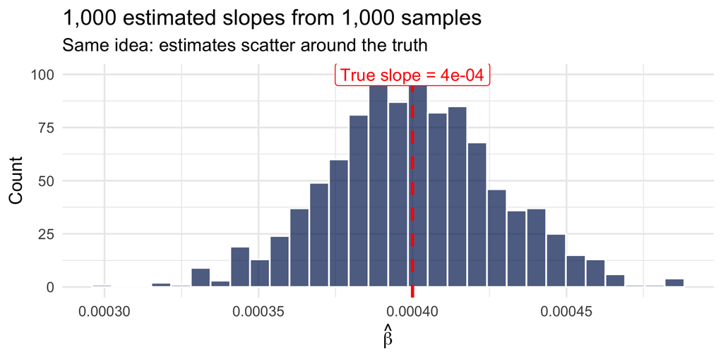

```r
set.seed(42)
true_beta <- 0.0004
n_sims <- 1000
betas <- numeric(n_sims)

for (i in 1:n_sims) {
  x <- runif(100, 500, 50000)
  y <- 55 + true_beta * x + rnorm(100, 0, 4)
  betas[i] <- coef(lm(y ~ x))[2]
}

ggplot(data.frame(betas = betas), aes(x = betas)) +
  geom_histogram(fill = "#011F5B", alpha = 0.7, bins = 30, color = "white") +
  geom_vline(xintercept = true_beta, color = "red", linewidth = 1.5, linetype = "dashed") +
  annotate("label", x = true_beta, y = 100,
           label = paste0("True slope = ", true_beta),
           color = "red", size = 6) +
  labs(x = expression(hat(beta)), y = "Count",
       title = "1,000 estimated slopes from 1,000 samples",
       subtitle = "Same idea: estimates scatter around the truth") +
  theme_minimal(base_size = 18)
```

## The Key Insight

Our estimate from any one sample is **one draw** from the sampling distribution.

- We don’t know exactly where in the distribution our estimate falls
- But we can estimate **how wide** the distribution is
- That width is the **standard error**

# Standard Errors and Confidence Intervals

## Standard Error

**Standard error** = the standard deviation of the sampling distribution.

- It measures: **how much would our estimate bounce around if we could repeat the study?**
- Small SE → our estimate is precise (the sampling distribution is narrow)
- Large SE → our estimate is imprecise (the sampling distribution is wide)

## What Affects the Standard Error?

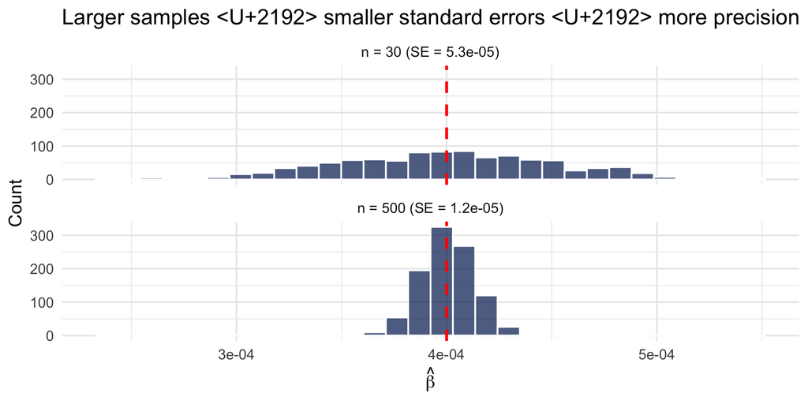

```r
set.seed(42)
true_beta <- 0.0004

betas_small <- numeric(1000)
betas_large <- numeric(1000)

for (i in 1:1000) {
  x_sm <- runif(30, 500, 50000)    # small sample
  x_lg <- runif(500, 500, 50000)   # large sample
  y_sm <- 55 + true_beta * x_sm + rnorm(30, 0, 4)
  y_lg <- 55 + true_beta * x_lg + rnorm(500, 0, 4)
  betas_small[i] <- coef(lm(y_sm ~ x_sm))[2]
  betas_large[i] <- coef(lm(y_lg ~ x_lg))[2]
}

compare <- rbind(
  data.frame(beta = betas_small, sample = paste0("n = 30 (SE = ", round(sd(betas_small), 6), ")")),
  data.frame(beta = betas_large, sample = paste0("n = 500 (SE = ", round(sd(betas_large), 6), ")"))
)

ggplot(compare, aes(x = beta)) +
  geom_histogram(fill = "#011F5B", alpha = 0.7, bins = 30, color = "white") +
  geom_vline(xintercept = true_beta, color = "red", linewidth = 1.2, linetype = "dashed") +
  facet_wrap(~sample, ncol = 1) +
  labs(x = expression(hat(beta)), y = "Count",
       title = "Larger samples → smaller standard errors → more precision") +
  theme_minimal(base_size = 16)
```

## Confidence Intervals

A **95% confidence interval** gives us a plausible range for the true value.

$$CI = \hat{\beta} \pm 1.96 \times SE$$

**Interpretation:** “If we repeated this study many times, about 95% of the confidence intervals would contain the true value.”

## Visualizing Confidence Intervals

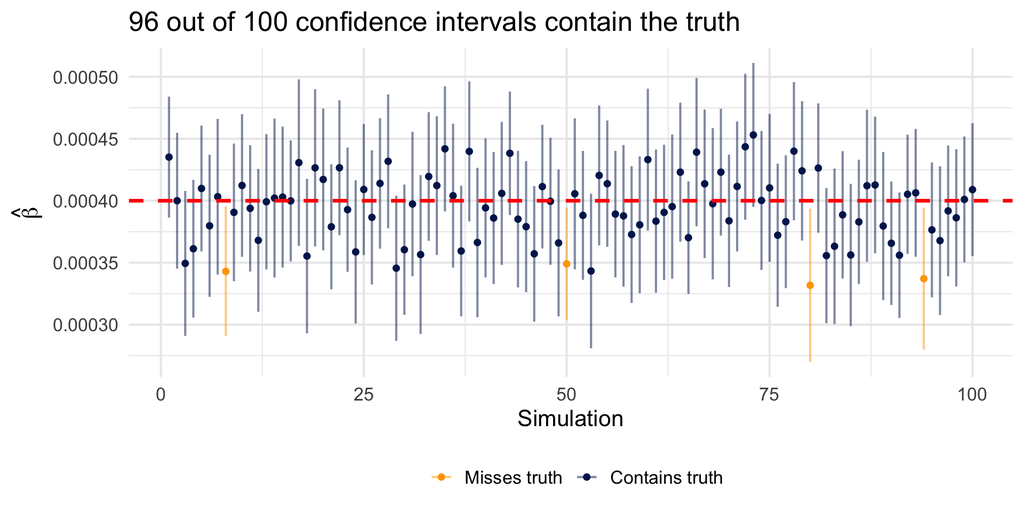

```r
set.seed(42)
n_sims <- 100
results <- data.frame(
  sim = 1:n_sims,
  beta = numeric(n_sims),
  se = numeric(n_sims)
)

for (i in 1:n_sims) {
  x <- runif(100, 500, 50000)
  y <- 55 + true_beta * x + rnorm(100, 0, 4)
  fit <- lm(y ~ x)
  results$beta[i] <- coef(fit)[2]
  results$se[i] <- summary(fit)$coefficients[2, 2]
}

results$lower <- results$beta - 1.96 * results$se
results$upper <- results$beta + 1.96 * results$se
results$covers <- results$lower <= true_beta & results$upper >= true_beta
coverage <- round(mean(results$covers) * 100)

ggplot(results, aes(x = sim, y = beta, color = covers)) +
  geom_point(size = 1.5) +
  geom_errorbar(aes(ymin = lower, ymax = upper), width = 0, alpha = 0.5) +
  geom_hline(yintercept = true_beta, color = "red", linewidth = 1.2, linetype = "dashed") +
  scale_color_manual(values = c("FALSE" = "orange", "TRUE" = "#011F5B"),
                     labels = c("Misses truth", "Contains truth")) +
  labs(x = "Simulation", y = expression(hat(beta)),
       title = paste0(coverage, " out of 100 confidence intervals contain the truth"),
       color = "") +
  theme_minimal(base_size = 16) +
  theme(legend.position = "bottom")
```

## Confidence Intervals in R

```r
# Using the model from last class
countries <- data.frame(gdp_pc = runif(80, 500, 50000))
set.seed(42)
countries$life_exp <- 55 + 0.0004 * countries$gdp_pc + rnorm(80, 0, 4)

model <- lm(life_exp ~ gdp_pc, data = countries)
confint(model)
```

```
                   2.5 %       97.5 %
(Intercept) 51.346742332 5.550163e+01
gdp_pc       0.000393425 5.188158e-04
```

“We are 95% confident that the true effect of a $1 increase in GDP per capita on life expectancy is between 3.9^{-4} and 5.2^{-4} years.”

# Hypothesis Testing

## Is This Coefficient Real or Just Noise?

**Null hypothesis ($H_0$):** There is no relationship. $\beta = 0$.

**Alternative hypothesis ($H_A$):** There is a relationship. $\beta \neq 0$.

The **p-value** answers: “If there were truly no relationship, how surprising would our estimate be?”

## Visualizing the p-value

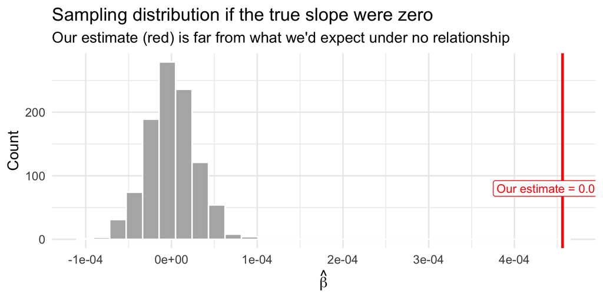

## Interpreting p-values

- **Small p-value** (< 0.05): our estimate would be very surprising if there were no relationship → we reject $H_0$
- **Large p-value** (> 0.05): our estimate is consistent with no relationship → we fail to reject $H_0$
- **p-value is NOT** the probability that the null is true
- **p-value is NOT** the probability of making an error

## The Stars in Regression Output

| Symbol | p-value | Meaning |
| --- | --- | --- |
| `***` | < 0.001 | Very strong evidence |
| `**` | < 0.01 | Strong evidence |
| `*` | < 0.05 | Evidence |
| `.` | < 0.1 | Weak evidence |
| (none) | > 0.1 | Not statistically significant |

These are conventions. The 0.05 threshold is arbitrary but widely used.

# Putting It All Together

## Full Circle: Reading `summary(lm())`

```r
summary(model)
```

```
Call:
lm(formula = life_exp ~ gdp_pc, data = countries)

Residuals:
     Min       1Q   Median       3Q      Max
-10.6400  -2.2398   0.8535   2.9123   9.0634

Coefficients:
             Estimate Std. Error t value Pr(>|t|)
(Intercept) 5.342e+01  1.043e+00   51.20   <2e-16 ***
gdp_pc      4.561e-04  3.149e-05   14.48   <2e-16 ***
---
Signif. codes:  0 '***' 0.001 '**' 0.01 '*' 0.05 '.' 0.1 ' ' 1

Residual standard error: 4.242 on 78 degrees of freedom
Multiple R-squared:  0.729, Adjusted R-squared:  0.7255
F-statistic: 209.8 on 1 and 78 DF,  p-value: < 2.2e-16
```

## Now You Can Read Every Number

- **Estimate**: the slope or intercept — association between $X$ and $Y$
- **Std. Error**: how much the estimate would vary across samples
- **t value**: Estimate $\div$ Std. Error — how many SEs away from zero
- **Pr(>|t|)**: p-value — would this be surprising if there were no relationship?
- **R-squared**: fraction of variation in $Y$ explained by $X$

## When Should You Trust Your Results?

- Is the **sample representative** of the population you care about?
- Are the **standard errors small** relative to the coefficient?
- Is the **p-value small** enough to rule out noise?
- Do the **residuals look well-behaved**?
- Does the result **make substantive sense**?

Statistics can’t save you from a bad sample or a bad research design.

## Connecting to What’s Next

- Now you know how to **run** a regression and **evaluate** the output
- But regression alone gives us **associations**, not causal effects
- Next: **Democracy and Development**
  - Uses regression with **fixed effects** to move toward causal claims
  - Fixed effects = a way to control for all time-invariant differences across units
  - It builds directly on multiple regression: $Y_{it} = \alpha_i + \beta X_{it} + \epsilon_{it}$

https://carolina-torreblanca.github.io/psci3200-globaldev-main/